# Baseball Data Visualization

## Author: Basobjit Halder

## Summary:

##### It consists of the record of 1157 MLB baseball players and their batting average, home runs, heights, weights etc. The data set can be found in the following link:

https://s3.amazonaws.com/udacity-hosted-downloads/ud507/baseball_data.csv.

The visualizations are created on tableau to answer the following questions:

1. Whether or not single handed dominated players have more success rates.
2. To determine the performence of the player on the basis of their avg,runs
3. How heights and weights of a the players effected their performence
4. To the star players so clubs can easily recognize the talents

## Design:

1. Visuals showing that the single handed dominated players have more success rates than both handed players.

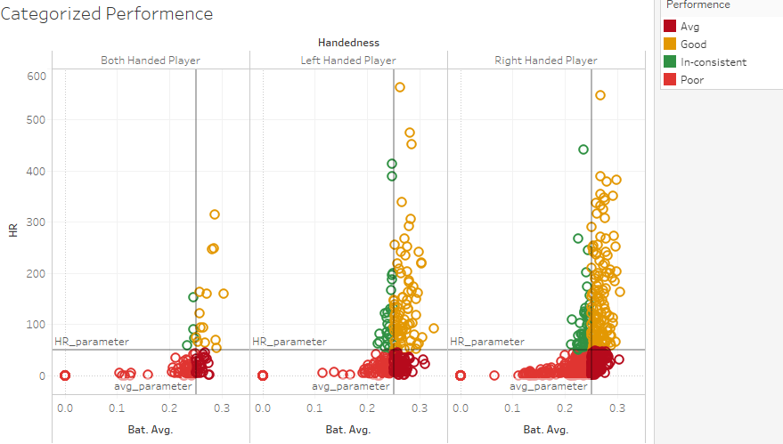

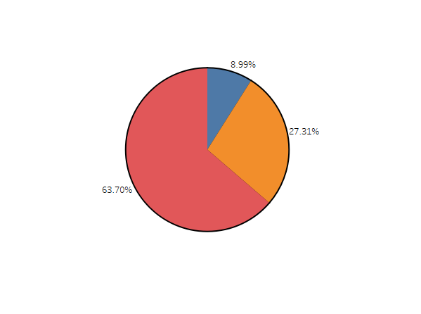

1. After analyzing the players details, visuals show the quadrants of the player in the category which helps to improve the poor performers and give them all the right training.

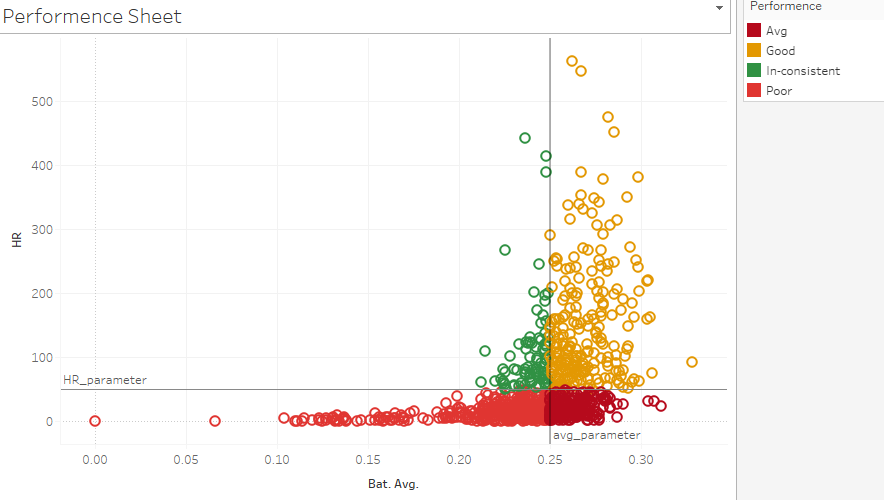

1. Visuals how performence are effected by the heights and weights of the players

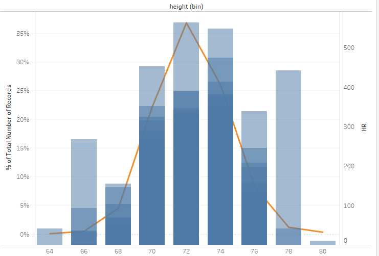

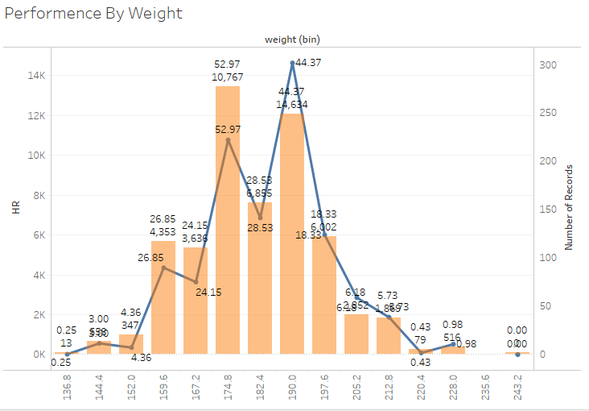

1. The star players so that clubs can easily pick them, and knows how games rely on them.

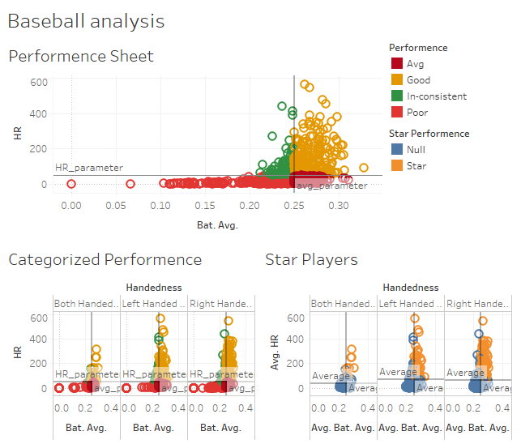

## Final tableau visualization link:

https://public.tableau.com/profile/basobjit.halder#!/vizhome/Baseballdataanalysis_15838511217180/StoryAnalysis?publish=yes